# Exploring the BRFSS data

## Setup

### Load packages

```r
library(ggplot2)
library(dplyr)
```

### Load data

Make sure your data and R Markdown files are in the same directory. When loaded your data file will be called `brfss2013`. Delete this note when before you submit your work.

```r
load("capstone_data.RData")
data <- brfss2013
```

## Part 1: Data

The `BRFS` dataset contains `491775` observations with `330` variables of different types - numerical(both discrete and continuous) and categorical(both normal and ordinal). It represents an `observational` `retrospective` study that was conducted in all US states, the District of Columbia and three U.S. territories, thus the population of interest is `US residents over 18 y.o.`. The `subject of interest` is `health-related risk behaviors, chronic health conditions, and use of preventive services` (cite: https://www.cdc.gov/brfss/about/index.htm). The data is collected thru in-house interviews as well as home and cell phone calls, the telephone numbers are obtained through `random-digit` dialing which mean that the dataset can be considered as `representative` of the entire population of US adult citizens. Nonetheless, it can have few sources of bias:

- `Non-response bias` - conducting `phone interviews` implies that significant `non-random` fraction of the randomly sampled people can refuse to take part in the survey (busy people) or not be able to answer the landline call due to being at work.
- `Convenience sample bias` - individuals who are easily accessible are more likely to be included in the sample, for instance, old people that are often at home are more likely to answer the landline phone call (or more agile/friendly people among a family are more likely to pick up the phone/willing to take part).
- `Voluntary response bias` - older/less healthy people have a stronger opinion over their health conditions compared to young/healthy ones.
- `Funding bias` - the CDC(Centers for Disease Control and Prevention) provides two types of funding: acquisition and assistance which may lead to a selection of outcomes, test samples, or test procedures that favor a study’s financial sponsor ([link](https://www.cdc.gov/funding/AboutCDCFunding.html)).

Taking in an account these potential sources of bias, the CDC is using the `iterative proportional fitting or ranking` methodology to `weight` the `BRFSS` data. This reduces the potential for bias and increases the representativeness of estimates. The weighting methodology allows for incorporation of a now-crucial variable - telephone ownership(landline/cell phone) into the weighting process. The `age`, `sex`, `categories` of `ethnicity`, `geographic regions within states`, `marital status`, `education level`, `home ownership` and `type of phone ownership` are used to weight BRFSS data. [1: CDC website - dropdown 15.](https://www.cdc.gov/brfss/about/brfss_faq.htm).

Since this is an `observational` study, it cannot be used for `causation` inference as it can only show a `correlation` between variables. The study does use `random sampling` to be representative over entire US population but for causation inference we need `random assignment` in a well-controlled experiment.

Let’s take a closer look on the dataset, the variables descriptions could be found in [Calculated Variables in Data Files[PDF - 421 KB]](https://www.cdc.gov/brfss/annual_data/2013/pdf/codebook13_llcp.pdf) file on the CDC website.

```r
head(data, n = 5)
```

```
##   X_state   fmonth   idate   imonth iday iyear            dispcode
## 1 Alabama  January 1092013  January    9  2013 Completed interview
## 2 Alabama  January 1192013  January   19  2013 Completed interview
## 3 Alabama  January 1192013  January   19  2013 Completed interview
## 4 Alabama  January 1112013  January   11  2013 Completed interview
## 5 Alabama February 2062013 February    6  2013 Completed interview
##        seqno      X_psu ctelenum pvtresd1 colghous stateres
## 1 2013000580 2013000580      Yes      Yes     <NA>      Yes
## 2 2013000593 2013000593      Yes      Yes     <NA>      Yes
## 3 2013000600 2013000600      Yes      Yes     <NA>      Yes
## 4 2013000606 2013000606      Yes      Yes     <NA>      Yes
## 5 2013000608 2013000608      Yes      Yes     <NA>      Yes
##               cellfon3 ladult numadult nummen numwomen   genhlth physhlth
## 1 Not a cellular phone   <NA>        2      1        1      Fair       30
## 2 Not a cellular phone   <NA>        2      1        1      Good        0
```

[output cut: 435 more lines]

```r
str(data)
```

```
## 'data.frame':    491775 obs. of  330 variables:
##  $ X_state  : Factor w/ 55 levels "0","Alabama",..: 2 2 2 2 2 2 2 2 2 2 ...
##  $ fmonth   : Factor w/ 12 levels "January","February",..: 1 1 1 1 2 3 3 3 4 4 ...
##  $ idate    : int  1092013 1192013 1192013 1112013 2062013 3272013 3222013 3042013 4242013 4242013 ...
##  $ imonth   : Factor w/ 12 levels "January","February",..: 1 1 1 1 2 3 3 3 4 4 ...
##  $ iday     : Factor w/ 31 levels "1","2","3","4",..: 9 19 19 11 6 27 22 4 24 24 ...
##  $ iyear    : Factor w/ 2 levels "2013","2014": 1 1 1 1 1 1 1 1 1 1 ...
##  $ dispcode : Factor w/ 2 levels "Completed interview",..: 1 1 1 1 1 1 1 1 1 1 ...
##  $ seqno    : int  2013000580 2013000593 2013000600 2013000606 2013000608 2013000630 2013000634 2013000644 2013001305 2013001338 ...
##  $ X_psu    : int  2013000580 2013000593 2013000600 2013000606 2013000608 2013000630 2013000634 2013000644 2013001305 2013001338 ...
##  $ ctelenum : Factor w/ 1 level "Yes": 1 1 1 1 1 1 1 1 1 1 ...
##  $ pvtresd1 : Factor w/ 2 levels "Yes","No": 1 1 1 1 1 1 1 1 1 1 ...
##  $ colghous : Factor w/ 1 level "Yes": NA NA NA NA NA NA NA NA NA NA ...
##  $ stateres : Factor w/ 1 level "Yes": 1 1 1 1 1 1 1 1 1 1 ...
##  $ cellfon3 : Factor w/ 1 level "Not a cellular phone": 1 1 1 1 1 1 1 1 1 1 ...
```

[output cut: 86 more lines]

Let’s take few random variables for analysis.

### genhlth - General health

From the `Codebook report` file:

```
General Health
Section: 1.1 Health Status Type: Num
Column: 80 SAS Variable Name: GENHLTH
Prologue:
Description: Would you say that in general, your health is:
Weighted
Value Label Frequency Percentage Percentage
1 Excellent 85,532 17.39 18.66
2 Very good 159,104 32.35 31.68
3 Good 150,548 30.61 31.11
4 Fair 66,700 13.56 13.31
5 Poor 27,909 5.68 4.76
7 Don’t know/Not Sure 969 0.20 0.18
9 Refused 1,004 0.20 0.29
BLANK Not asked or Missing 7
```

```r
data %>% group_by(genhlth) %>% summarise(n = n())
```

```
## # A tibble: 6 x 2
##     genhlth      n
##      <fctr>  <int>
## 1 Excellent  85482
## 2 Very good 159076
## 3      Good 150555
## 4      Fair  66726
## 5      Poor  27951
## 6      <NA>   1985
```

This is an interesting variable as it indicates `subjective` general health rating of a respondent and can be used in correlational exploratory data analysis with many variables.

### sleptim1 - How much time do you sleep

From the `Codebook report` file:

```
How Much Time Do You Sleep
Section: 4.1 Inadequate Sleep Type: Num
Column: 91-92 SAS Variable Name: SLEPTIM1
Prologue: I would like to ask you about your sleep pattern.
Description: On average, how many hours of sleep do you get in a 24-hour period?
Weighted
Value Value Label Frequency Percentage Percentage
1 - 24 Number of hours [1-24] 484,401 98.50 98.76
77 Don’t know/Not Sure 6,540 1.33 1.09
99 Refused 832 0.17 0.15
```

```r
data %>% group_by(sleptim1) %>% summarise(n = n())
```

```
## # A tibble: 28 x 2
##    sleptim1      n
##       <int>  <int>
##  1        0      1
##  2        1    228
##  3        2   1076
##  4        3   3496
##  5        4  14261
##  6        5  33436
##  7        6 106197
##  8        7 142469
##  9        8 141102
## 10        9  23800
## # ... with 18 more rows
```

Looking further into the issue, we can see that the long-sleeping answers take less then `0.0022` which is `0.22` percent (`1066 / (483322 + 1066)`):

```r
data %>% filter(!is.na(sleptim1)) %>% mutate(sleep2 = ifelse(sleptim1 < 15, "norm", "many")) %>% group_by(sleep2) %>% summarise(n = n())
```

```
## # A tibble: 2 x 2
##   sleep2      n
##    <chr>  <int>
## 1   many   1066
## 2   norm 483322
```

This variable is interesting for us since an amount of sleep might have a tremendous impact on `objective` and `subjective` health of a human being, thus would be interesting to explore the correlation between sleep and other variables. Also, some habits, especially the ones that involve consuming different substances (tobacco, alcohol, drugs) might have energizing effect thus we might see a correlation with such variables.

### misnervs - How often feel nervous past 30 days

From the `Codebook report` file:

```
How often feel nervous past 30 days
Module: 17.1 Mental Illness & Stigma Type: Num
Column: 418 SAS Variable Name: MISNERVS
Prologue:
Description: About how often during the past 30 days did you feel nervous- would you say all of the time, most of the time, some
of the time, a little of the time or none of the time?
Weighted
Value Value Label Frequency Percentage Percentage
1 All 715 2.15 2.90
2 Most 1,129 3.40 4.05
3 Some 4,675 14.08 14.53
4 A little 9,636 29.01 28.34
5 None 16,056 48.35 45.19
7 Don’t know/Not sure 113 0.34 0.24
9 Refused 887 2.67 4.76
BLANK Not asked or Missing 458,562
```

```r
str(data$misnervs)
```

```
##  Factor w/ 5 levels "All","Most","Some",..: 3 4 5 4 NA NA NA NA NA NA ...
```

From the log above, `Factor w/ 5 levels "All","Most","Some",..: 3 4 5 4 NA NA NA NA NA NA ...`, we can see that the variable is a `categorical ordinal` variable (Factor) with levels “All”, “Most”, “A little” and “None” which represents a subjective respondent nervous feeling past `30 days`. The majority of the observations (about `92.65%`) are `Don’t know/Not sure`, `Refused` and missed(`NA`) values:

```r
data %>% group_by(misnervs) %>% summarize(n = n()/nrow(data))
```

```
## # A tibble: 6 x 2
##   misnervs           n
##     <fctr>       <dbl>
## 1      All 0.001675563
## 2     Most 0.002615017
## 3     Some 0.010726450
## 4 A little 0.021863657
## 5     None 0.036618372
## 6     <NA> 0.926500940
```

This variable might be interesting for us to try to find correlations with a `mental load` and `mental health` of the population. Also, we can try to find a correlation between the `physical health` and the `feeling nervous`(mental health) variables.

## Part 2: Research questions

Now, when we understood what some of the variables are and what they may imply, we can start asking research questions.

**Research question 1:**

> Are the people who less `physical active` (exerany2) have more chance to `feeling restless`(misrstls)? (2 variables)

The research question can be interesting for finding a correlation between physical activity level and mental issues. The question is of interest for the author of the research because he often `feels restless` too.

**Research question 2:**

> Do `veterans`(veteran3) that are `employed` (employ1) are alos less `feel depressed`(misdeprd)?

Veterans rehabilitation and integration is a big challenge for the society. The research question can reveal if veterans occupation correlate with how well they do in a rehabilitation process.

**Research question 3:**

> Are people who eat`fruits`(fruit1) or `dark vegetables`(fvgreen) are also have better `general health`(genhlth)?

The research question can be interesting to bast/confirm a common myth (or not myth) that eating a lot of fruits/vegetables is good for human’s health. If we will not find any correlation this will mean that the variables might be independent. In the case, if the correlation is found this might suggest that the myth tells truth. In any case, further exploration with a controlled experiment will be needed, which will infer variables dependence or independence (causation).

## Part 3: Exploratory data analysis

**Research question 1:**

> Are the people who less `physical active` (exerany2) have more chance to `feeling restless`(misrstls)? (2 variables)

Let see what data do we have:

```r
data %>% group_by(exerany2) %>% summarize(n = n())
```

```
## # A tibble: 3 x 2
##   exerany2      n
##     <fctr>  <int>
## 1      Yes 332464
## 2       No 125282
## 3     <NA>  34029
```

```r
data %>% group_by(misrstls) %>% summarize(n = n())
```

```
## # A tibble: 6 x 2
##   misrstls      n
##     <fctr>  <int>
## 1      All    963
## 2     Most   1193
## 3     Some   5355
## 4 A little   8204
## 5     None  20322
## 6     <NA> 455738
```

Both of them have some fraction of `NA` observations. Let’s filter out them for the sake of convinience:

```r
data1 <- data %>% filter(!is.na(misrstls), !is.na(exerany2));
data1 %>% group_by(misrstls, exerany2) %>% summarize(n = n())
```

```
## # A tibble: 10 x 3
## # Groups:   misrstls [?]
##    misrstls exerany2     n
##      <fctr>   <fctr> <int>
##  1      All      Yes   557
##  2      All       No   401
##  3     Most      Yes   778
##  4     Most       No   415
##  5     Some      Yes  3827
##  6     Some       No  1521
##  7 A little      Yes  6397
##  8 A little       No  1795
##  9     None      Yes 15468
## 10     None       No  4804
```

Lets build a segmeted stardantized barplot with proportions of observations in variaous categories:

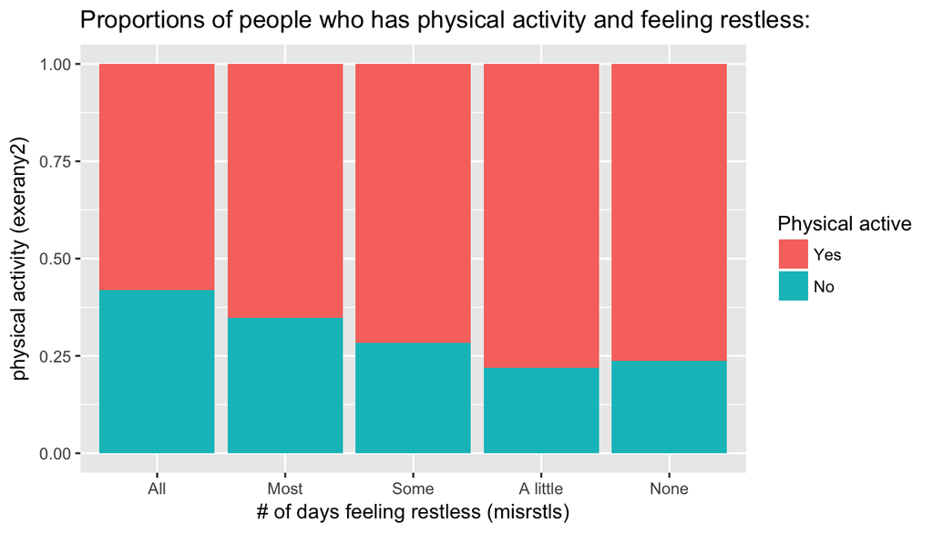

```r
ggplot(data = data1, aes(x = misrstls, fill = exerany2)) + geom_bar(position = "fill") +
  labs(title="Proportions of people who has physical activity and feeling restless:") +
  xlab("# of days feeling restless (misrstls)") +
  ylab("physical activity (exerany2)") +
  scale_fill_discrete(name = "Physical active")
```

The difference in percentage of different levels might suggest correlation between the variables. We can notice that levels `All`/`Most` and `Some`/`Little` might have a subtle differences in their meaning and can be confused by the respondents. Let’s create a new variable and merge these paired levels:

```r
# create new data frame with a new Factor `misrstls2` - represent merged categories in pairs:
#   - ("All" or "Most") -> "A lot"
#   - ("Some" or "A little" or "None") -> "A little or none"
data2 <- data1 %>% mutate(misrstls2 = ifelse((misrstls == "All" | misrstls == "Most"), "A lot", "A little or none"))
# group the new dataframe by new variable and summarise it
data2 %>% group_by(misrstls2) %>% summarize(n = n())
```

```
## # A tibble: 2 x 2
##          misrstls2     n
##              <chr> <int>
## 1 A little or none 33812
## 2            A lot  2151
```

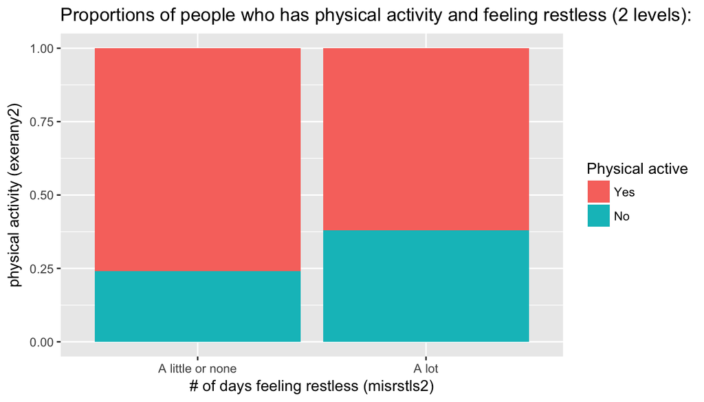

```r
# use the new variable with two levels to plot the same standartized barplot
ggplot(data = data2, aes(x = misrstls2, fill = exerany2)) + geom_bar(position = "fill") +
  labs(title="Proportions of people who has physical activity and feeling restless (2 levels):") +
  xlab("# of days feeling restless (misrstls2)") +
  ylab("physical activity (exerany2)") +
  scale_fill_discrete(name = "Physical active")
```

#### Recap

**Research question 2:**

> Do `veterans`(veteran3) that are `employed` (employ1) are alos less `feel depressed`(misdeprd)?

LEt’s see what data do we have:

```r
data %>% group_by(veteran3) %>% summarize(n = n())
```

```
## # A tibble: 3 x 2
##   veteran3      n
##     <fctr>  <int>
## 1      Yes  61446
## 2       No 429583
## 3     <NA>    746
```

```r
data %>% group_by(employ1) %>% summarize(n = n())
```

```
## # A tibble: 9 x 2
##                            employ1      n
##                             <fctr>  <int>
## 1               Employed for wages 202200
## 2                    Self-employed  39832
## 3   Out of work for 1 year or more  14074
## 4 Out of work for less than 1 year  12242
## 5                      A homemaker  31647
## 6                        A student  12682
## 7                          Retired 138259
## 8                   Unable to work  37453
## 9                             <NA>   3386
```

```r
data %>% group_by(misdeprd) %>% summarize(n = n())
```

```
## # A tibble: 6 x 2
##   misdeprd      n
##     <fctr>  <int>
## 1      All    259
## 2     Most    539
## 3     Some   1567
## 4 A little   2539
## 5     None  31202
## 6     <NA> 455669
```

As we can see we have 3 categorical variables, only the `misdeprd` is `ordinal`. All of the variables have some fraction on `NA` values, let’s filter them out for the sake of convinience, also since we are interested only in veterans, let’s filter out all other observations:

```r
data_veterans <- data %>% filter(!is.na(veteran3), veteran3 == 'Yes', !is.na(employ1), !is.na(misdeprd))

data_veterans %>% group_by(veteran3) %>% summarize(n = n())
```

```
## # A tibble: 1 x 2
##   veteran3     n
##     <fctr> <int>
## 1      Yes  4681
```

```r
data_veterans %>% group_by(employ1) %>% summarize(n = n())
```

```
## # A tibble: 8 x 2
##                            employ1     n
##                             <fctr> <int>
## 1               Employed for wages  1409
## 2                    Self-employed   302
## 3   Out of work for 1 year or more    90
## 4 Out of work for less than 1 year    65
## 5                      A homemaker    23
## 6                        A student    36
## 7                          Retired  2498
## 8                   Unable to work   258
```

```r
data_veterans %>% group_by(misdeprd) %>% summarize(n = n())
```

```
## # A tibble: 5 x 2
##   misdeprd     n
##     <fctr> <int>
## 1      All    30
## 2     Most    58
## 3     Some   157
## 4 A little   268
## 5     None  4168
```

Also we can notice tht the `employ1` have multiple levels to describe a type of `unemployement`, let create a new variable with just `2` levels - `working` and `not working`:

```r
data_veterans_empl <- data_veterans %>% mutate(employ1Cat = ifelse((employ1 == 'Employed for wages' | employ1 == 'Self-employed'), 'working', 'not working'))
```

Finally, lets create a standartized barplot for the veterans employement/feeling depressed categories:

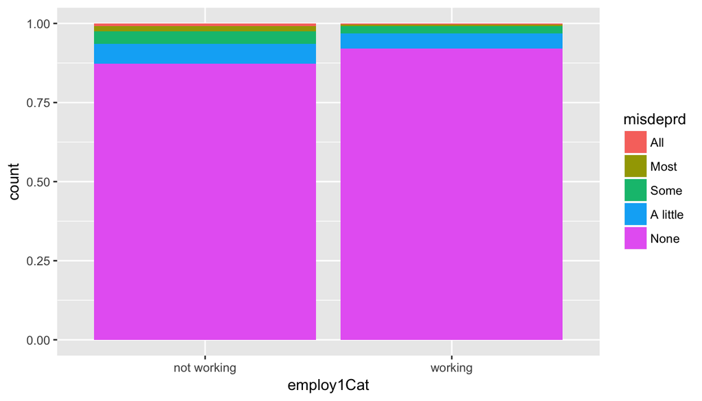

```r
ggplot(data = data_veterans_empl, aes(x = employ1Cat, fill = misdeprd)) + geom_bar(position = "fill")
```

The variables seem to have some correlations but since the `Feel depressed - None` level takes almost entire bar it is hard to spot it. Let’s rephrase our question - “Among the veterans that have signs of depression what fractions are fall into `not working` and `working` categories?”, to answer this question let’s remove all `Feel depressed - None` levels and create the standartised barplot again:

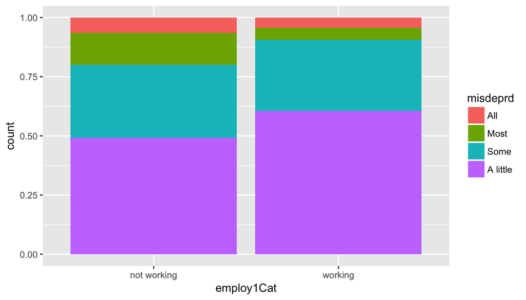

```r
data_veterans_empl_depr <- data_veterans_empl %>% filter(misdeprd != 'None')
ggplot(data = data_veterans_empl_depr, aes(x = employ1Cat, fill = misdeprd)) + geom_bar(position = "fill")
```

As we can see, the level of depression varies among the `not working` and `working` levels, the most significant difference can be spotted for the `A little` (`11%`) and `Most` (`9%`) levels. With a moderate confidence, we can state a correlation.

#### Recap

As we saw, the majority of veterans ~`90%` does not feel depressed at all, besides that fact we have found that there is indeed some correlation between `veteran occupation status` and `depression levels` thus veterans that are not employed are more likely to feel depressed.

**Research question 3:**

> Are people who eat`fruits`(fruit1) or `dark vegetables`(fvgreen) are also have better `general health`(genhlth)?

Let see what data do we have:

```r
data %>% group_by(fruit1) %>% summarize(n = n())
```

```
## # A tibble: 145 x 2
##    fruit1      n
##     <int>  <int>
##  1      0  17894
##  2      1      1
##  3      2      2
##  4    101 116116
##  5    102  62156
##  6    103  23802
##  7    104   5350
##  8    105   2733
##  9    106    535
## 10    107    264
## # ... with 135 more rows
```

```r
data %>% group_by(fvgreen) %>% summarize(n = n())
```

```
## # A tibble: 131 x 2
##    fvgreen     n
##      <int> <int>
##  1       0 36455
##  2       1     1
##  3       2     2
##  4     101 63411
##  5     102 17572
##  6     103  3473
##  7     104   821
##  8     105   594
##  9     106    61
## 10     107    64
## # ... with 121 more rows
```

```r
data %>% group_by(genhlth) %>% summarize(n = n())
```

```
## # A tibble: 6 x 2
##     genhlth      n
##      <fctr>  <int>
## 1 Excellent  85482
## 2 Very good 159076
## 3      Good 150555
## 4      Fair  66726
## 5      Poor  27951
## 6      <NA>   1985
```

As we can see, the `general health`(genhlth) is the only categorical(ordinal) variable among 3, the `fruit1` and `fvgreen` are variables of discrete numerical type (integers). All of them have `NA` variables, let’s get rid of them:

```r
data_fruit <- data %>% filter(!is.na(genhlth), !is.na(fruit1), !is.na(fvgreen))
cat(sprintf("%f observations survived - %f percent", nrow(data_fruit), (nrow(data_fruit) / nrow(data))*100) )
```

```
## 450791.000000 observations survived - 91.666107 percent
```

Let’s look into how the data encoded in the `fvgreen` variable:

```
101 - 199 Times per day 86,099 18.54 18.49
201 - 299 Times per week 163,664 35.25 35.69
301 - 399 Times per month 168,235 36.23 34.79
1 Less than one time per month 2,141 0.46 0.34
0 Never 36,487 7.86 7.58
```

We can see that the data categorized in periods with descrete numbers, we can create new factors out of this for the sake of convinience:

`555 Never` + `300 Less than one time per month` + `<= 1 times per week` + `<= 4 times per month` -> `never` `<= 2 times per week` + `<= 9 times per month` -> ‘a little’ `<= 4 times per week` + `<= 15 times per month` -> ‘medium’ `<= 5 times per week` + `<= 20 times per month` -> ‘most’ `<= 7 times per week` + `<= 31 times per month` -> ‘all’

```r
data_fruit <- data_fruit %>% mutate(fvgreenCat =
  ifelse(
    fvgreen == 0 | # never
    fvgreen == 1 | # less than one time per week
    fvgreen == 2 | # less than one time per month
    fvgreen == 300 | # less than one time per month
    (fvgreen == 201) | # less than one time pre week
    (fvgreen >= 301 & fvgreen <= 304) # less than 4 times pre week
    ,
    '0. never',
    ifelse(
      (fvgreen >= 202 & fvgreen <= 202) | # <= 2 times per week
      (fvgreen >= 305 & fvgreen <= 309) # <= 9 times per month
      ,
      '1. a little',
      ifelse(
        (fvgreen >= 203 & fvgreen <= 204) | # <= 4 times per week
        (fvgreen >= 310 & fvgreen <= 315) # <= 15 times per month
        ,
        '2. medium',
        ifelse(
          (fvgreen >= 205 & fvgreen <= 205) | # <= 5 times per week
          (fvgreen >= 316 & fvgreen <= 320) # <= 20 times per month
          ,
          '3. most',
          ifelse(
            (fvgreen >= 206 & fvgreen <= 207) | # <= 7 times per week
            (fvgreen == 101) | # <= 7 times per week / 1 times a day
            (fvgreen >= 321 & fvgreen <= 331) # <= 31 times per month
            ,
            '4. all',
            ifelse(
              (fvgreen >= 102 & fvgreen <= 102) | ## twice a day
              (fvgreen >= 208 & fvgreen <= 212) |
              (fvgreen >= 331 & fvgreen <= 340)
              ,
              '5. all+', # (multiple times a day),
              ifelse(
                (fvgreen >= 103 & fvgreen <= 105) | ## 3-5 times a day a day
                (fvgreen >= 213 & fvgreen <= 226) |
                (fvgreen >= 332 & fvgreen <= 364)
                ,
                '6. all++',
                ifelse(
                  (fvgreen >= 106 & fvgreen < 200) |  ## 6+ times a day a day
                  (fvgreen >= 227 & fvgreen < 300) |
                  (fvgreen >= 365 & fvgreen <= 400)
                ,
                '7. all+++',
                'error'
                )
              )
            )
          )
        )
      )
    )
  )
)
```

For sanity check, let’s see how many observations were categorized as `error`:

```r
# uncomment to see where the error is
# data_fruit %>% filter(fvgreenCat == 'error') %>% group_by(fvgreenCat, fvgreen) %>% summarise(n = n())
data_fruit %>% group_by(fvgreenCat) %>% summarise(n = n())
```

```
## # A tibble: 8 x 2
##    fvgreenCat      n
##         <chr>  <int>
## 1    0. never 116698
## 2 1. a little  69471
## 3   2. medium 109978
## 4     3. most  39922
## 5      4. all  89712
## 6     5. all+  18759
## 7    6. all++   5891
## 8   7. all+++    360
```

Looks good, all the cases were successfully recategorized.

Now let’s build a starndartized barplot with fractions of all categories:

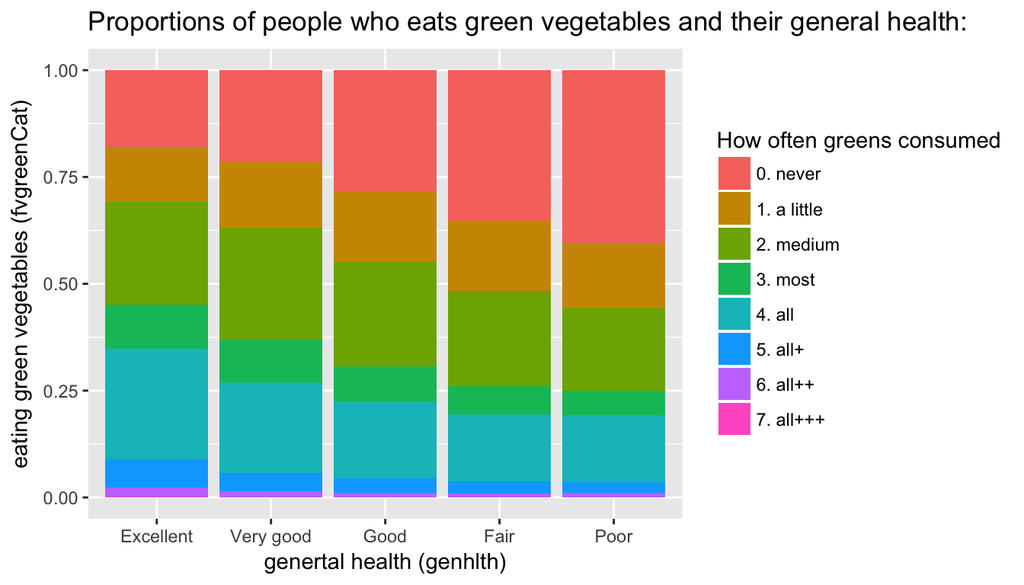

```r
ggplot(data = data_fruit, aes(x = genhlth, fill = fvgreenCat)) + geom_bar(position = "fill") +
  labs(title="Proportions of people who eats green vegetables and their general health:") +
  xlab("genertal health (genhlth)") +
  ylab("eating green vegetables (fvgreenCat)") +
  scale_fill_discrete(name = "How often greens consumed")
```

The interesting part is the correlation direction for each level:

- For the `0. never` level vs `genhlth` we see a positive direction of the correlation
- For the `1. a little` level vs `genhlth` we see no trend at all
- Starting from the `2. a medium` level vs `genhlth` the trend starts to be negative

Lets plot each of the greens levels correlations to illustrate that:

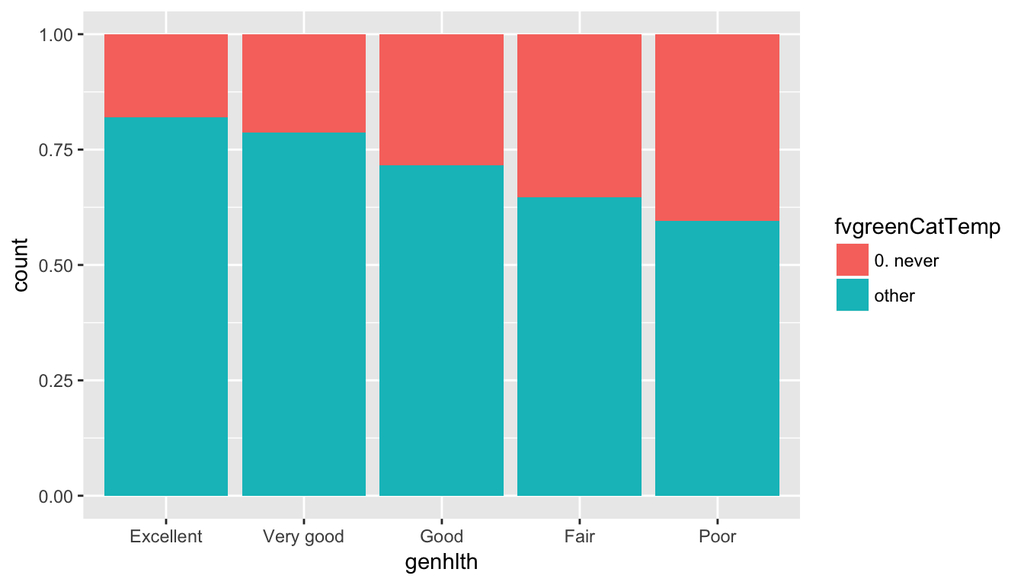

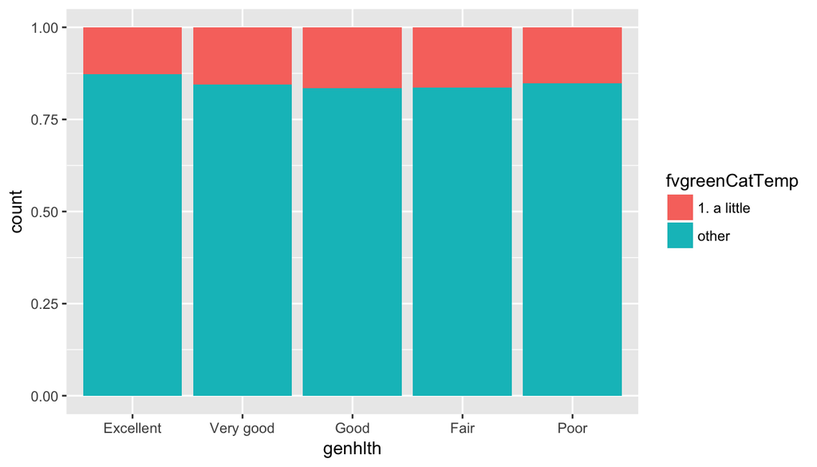

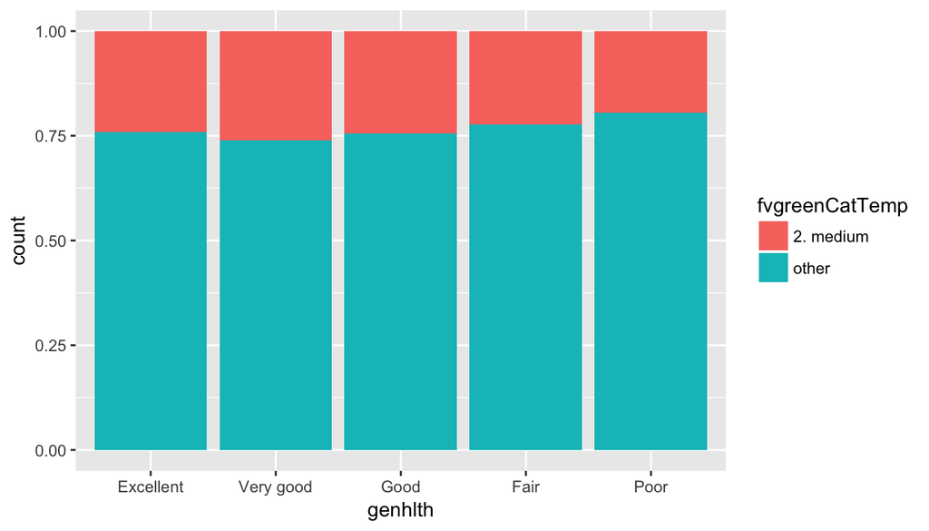

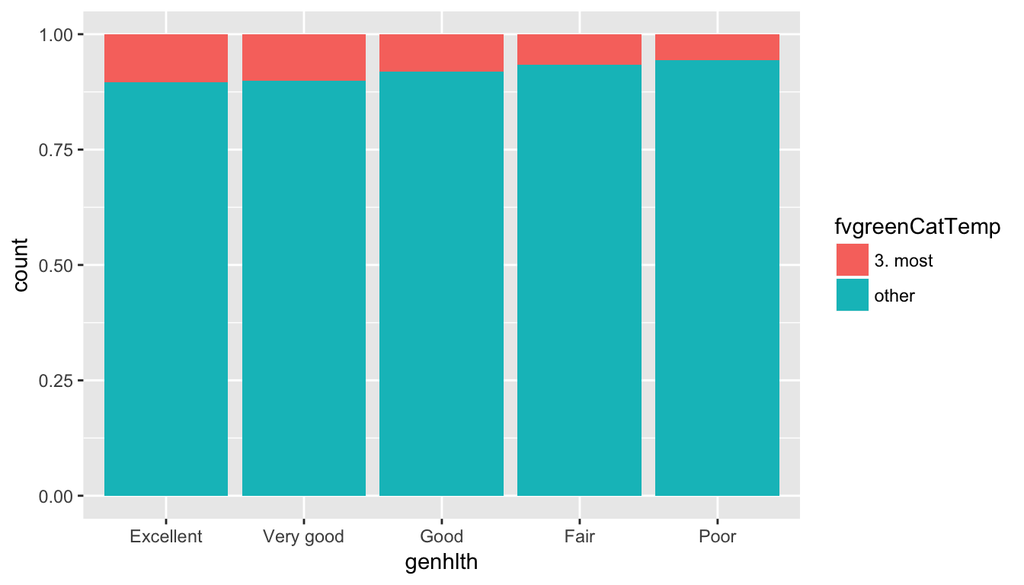

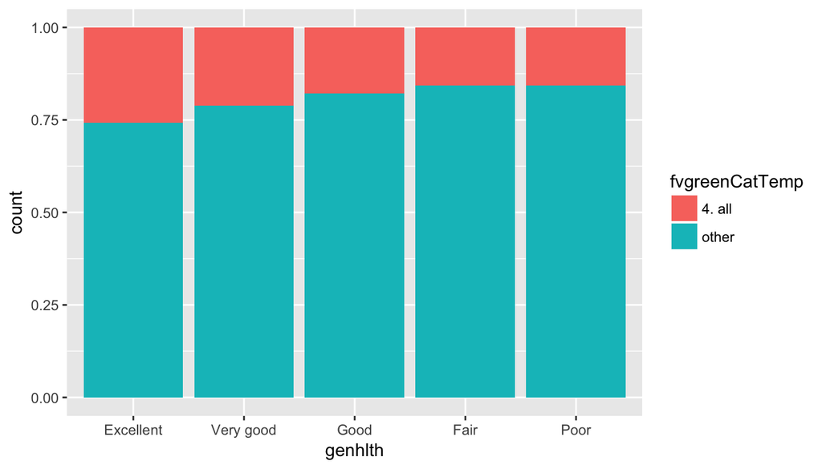

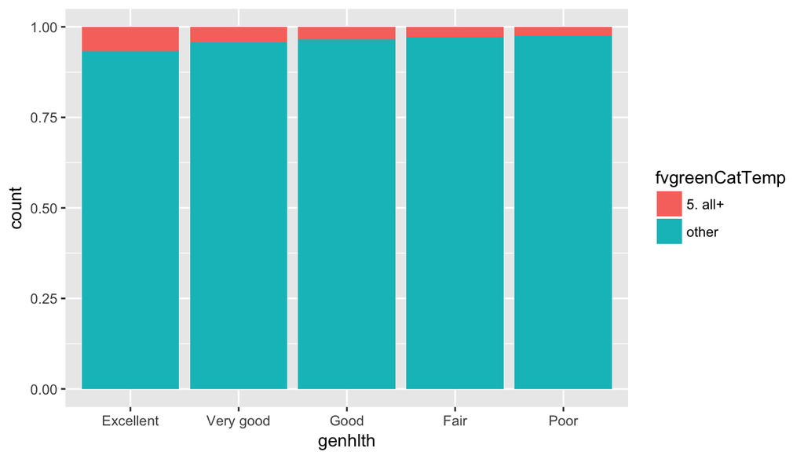

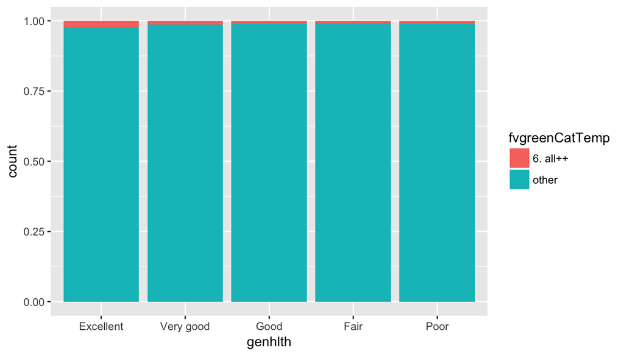

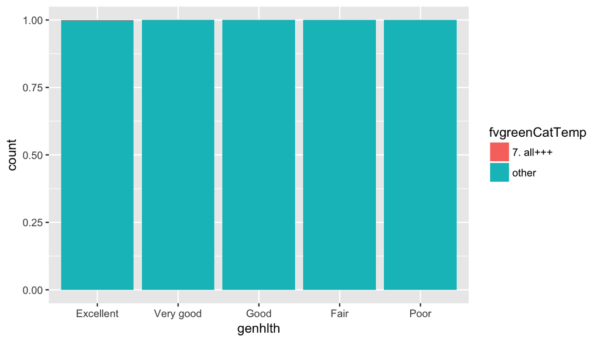

```r
a = c('0. never', '1. a little', '2. medium', '3. most', '4. all', '5. all+',  '6. all++',  '7. all+++')
for(i in a) {
  data_fruit_temp <- data_fruit %>% mutate(fvgreenCatTemp = ifelse(fvgreenCat == i, i, 'other'))
  print(ggplot(data = data_fruit_temp, aes(x = genhlth, fill = fvgreenCatTemp)) + geom_bar(position = "fill"))
}
```

The point where the correlation changes direction might be interesting in further data exploration if we will conduct a controlled experiment.

#### Fruits consumtion vs General health

We had found the correlation for the vegetables, let’s see if there any correlation with for `general health` and `amount of fruits eaten`. First let’s see the data:

```r
data_fruit %>% group_by(fruit1) %>% summarise(n = n())
```

```
## # A tibble: 142 x 2
##    fruit1      n
##     <int>  <int>
##  1      0  17344
##  2      2      1
##  3    101 114015
##  4    102  61385
##  5    103  23535
##  6    104   5291
##  7    105   2687
##  8    106    524
##  9    107    248
## 10    108     77
## # ... with 132 more rows
```

As we can see the data encoded exactly the same as the data for the vegetables(`fvgreen`), let apply exactly the same transformation for it:

```r
data_fruit <- data_fruit %>% mutate(fruit1Cat =
  ifelse(
    fruit1 == 0 | # never
    fruit1 == 1 | # less than one time per week
    fruit1 == 2 | # less than one time per month
    fruit1 == 300 | # less than one time per month
    (fruit1 == 201) | # less than one time pre week
    (fruit1 >= 301 & fruit1 <= 304) # less than 4 times pre week
    ,
    '0. never',
    ifelse(
      (fruit1 >= 202 & fruit1 <= 202) | # <= 2 times per week
      (fruit1 >= 305 & fruit1 <= 309) # <= 9 times per month
      ,
      '1. a little',
      ifelse(
        (fruit1 >= 203 & fruit1 <= 204) | # <= 4 times per week
        (fruit1 >= 310 & fruit1 <= 315) # <= 15 times per month
        ,
        '2. medium',
        ifelse(
          (fruit1 >= 205 & fruit1 <= 205) | # <= 5 times per week
          (fruit1 >= 316 & fruit1 <= 320) # <= 20 times per month
          ,
          '3. most',
          ifelse(
            (fruit1 >= 206 & fruit1 <= 207) | # <= 7 times per week
            (fruit1 == 101) | # <= 7 times per week / 1 times a day
            (fruit1 >= 321 & fruit1 <= 331) # <= 31 times per month
            ,
            '4. all',
            ifelse(
              (fruit1 >= 102 & fruit1 <= 102) | ## twice a day
              (fruit1 >= 208 & fruit1 <= 212) |
              (fruit1 >= 331 & fruit1 <= 340)
              ,
              '5. all+', # (multiple times a day),
              ifelse(
                (fruit1 >= 103 & fruit1 <= 105) | ## 3-5 times a day a day
                (fruit1 >= 213 & fruit1 <= 226) |
                (fruit1 >= 332 & fruit1 <= 364)
                ,
                '6. all++',
                ifelse(
                  (fruit1 >= 106 & fruit1 < 200) |  ## 6+ times a day a day
                  (fruit1 >= 227 & fruit1 < 300) |
                  (fruit1 >= 365 & fruit1 <= 400)
                ,
                '7. all+++',
                'error'
                )
              )
            )
          )
        )
      )
    )
  )
)
```

Now let’s check if there any errors:

```r
# uncomment to see where the error is
# data_fruit %>% filter(fruit1Cat == 'error') %>% group_by(fruit1Cat, fruit1) %>% summarise(n = n())
data_fruit %>% group_by(fruit1Cat) %>% summarise(n = n())
```

```
## # A tibble: 8 x 2
##     fruit1Cat      n
##         <chr>  <int>
## 1    0. never  60171
## 2 1. a little  40204
## 3   2. medium  75486
## 4     3. most  30384
## 5      4. all 146334
## 6     5. all+  63371
## 7    6. all++  33387
## 8   7. all+++   1454
```

All the cases were successfully recategorized - no errors found. Now let’s build a starndartized barplot with fractions of all levels:

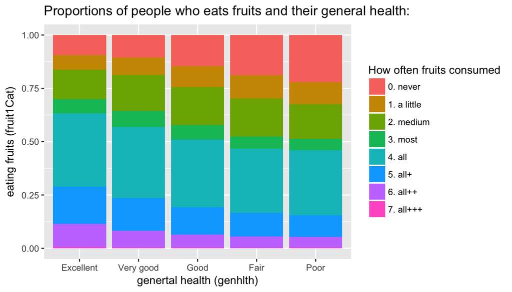

```r
ggplot(data = data_fruit, aes(x = genhlth, fill = fruit1Cat)) + geom_bar(position = "fill") +
  labs(title="Proportions of people who eats fruits and their general health:") +
  xlab("genertal health (genhlth)") +
  ylab("eating fruits (fruit1Cat)") +
  scale_fill_discrete(name = "How often fruits consumed")
```

The difference in the distributions among levels again suggests a strong correlation, not as strong as with greens though (about `10%` difference for the extremes - `0. never` vs `7. all+++`).

Let’s see if there and when the correlation direction changes:

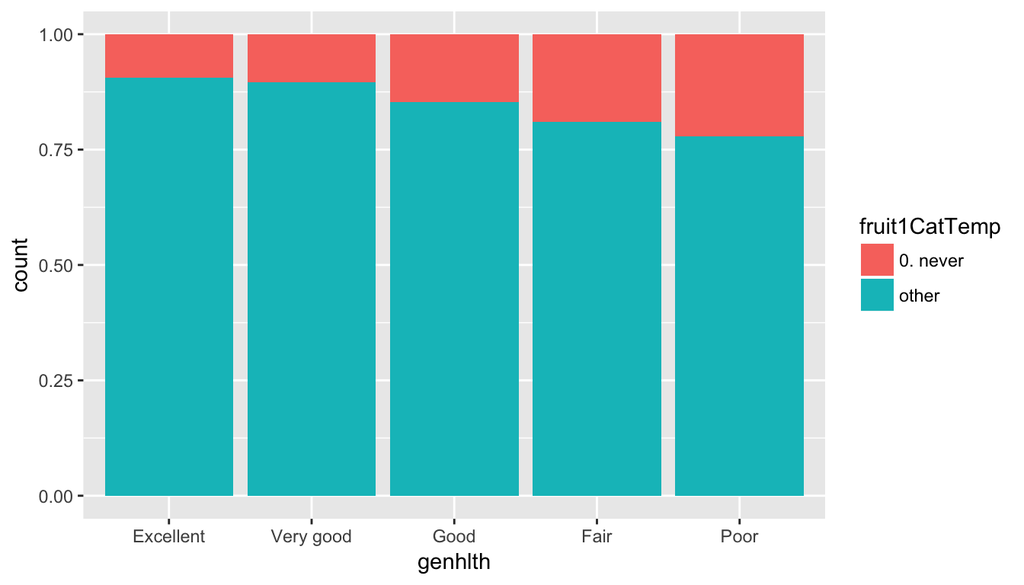

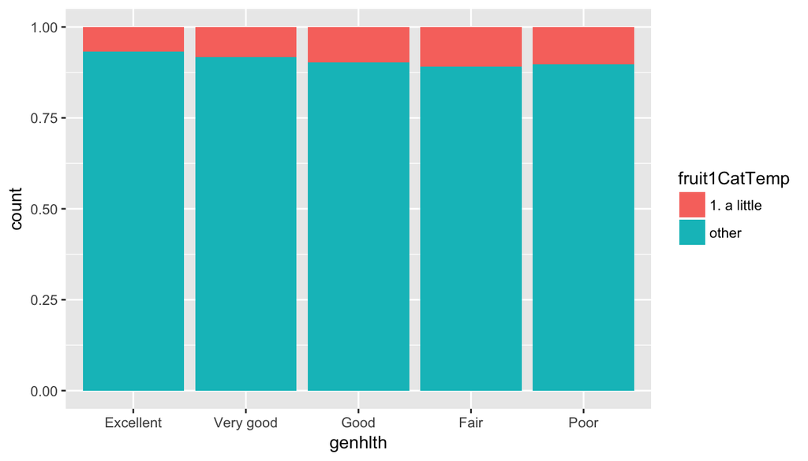

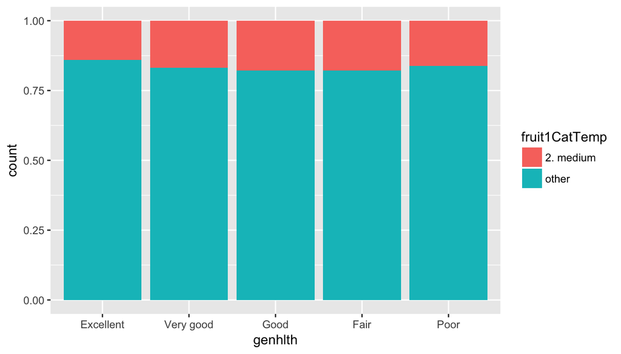

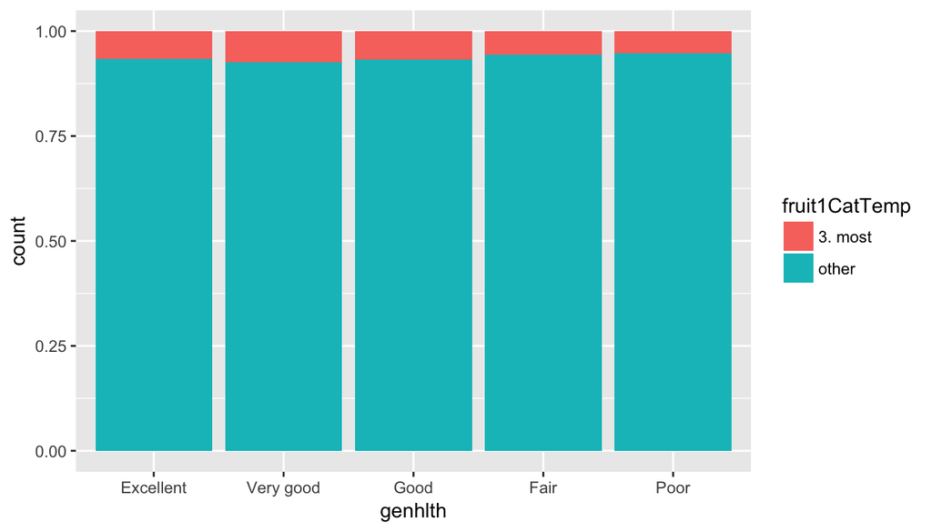

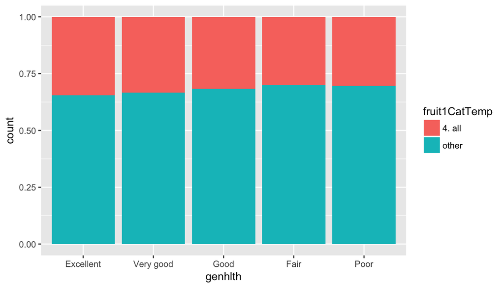

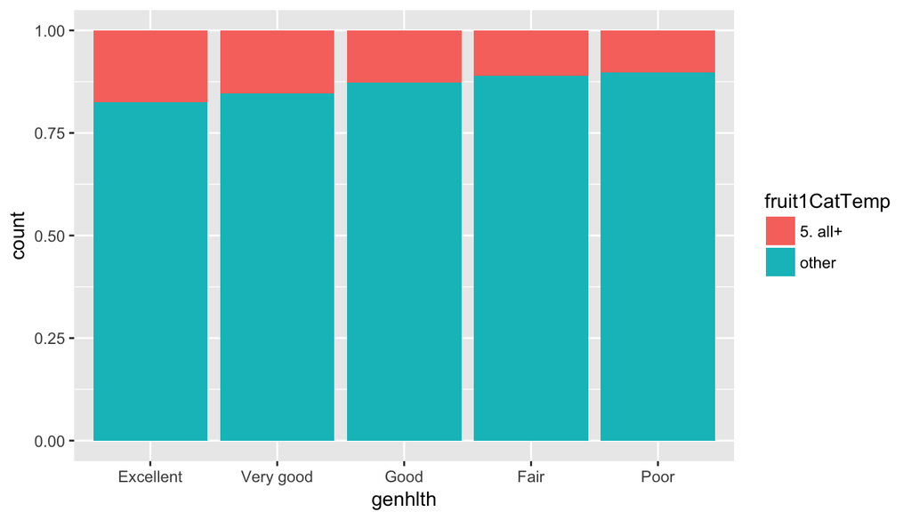

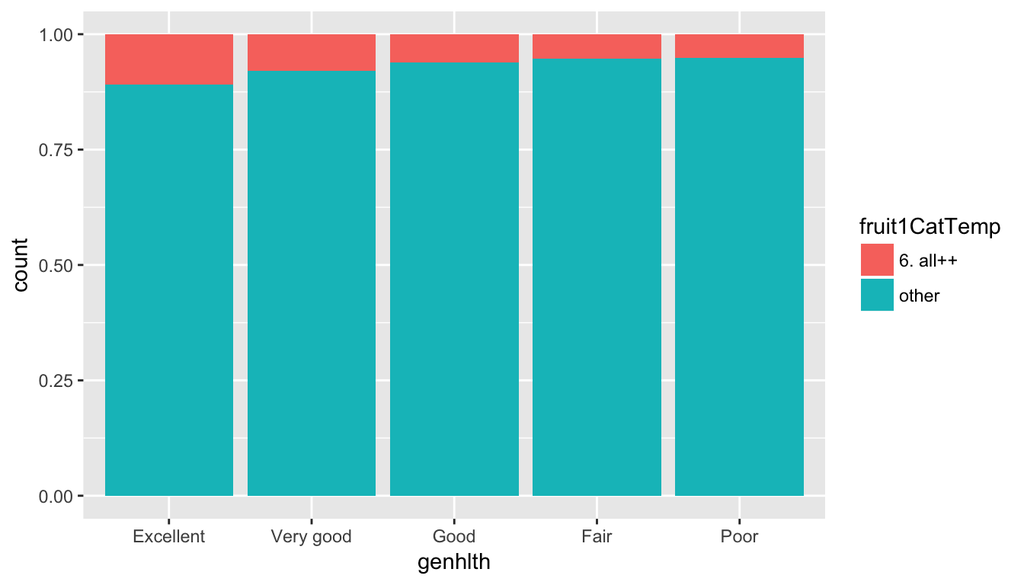

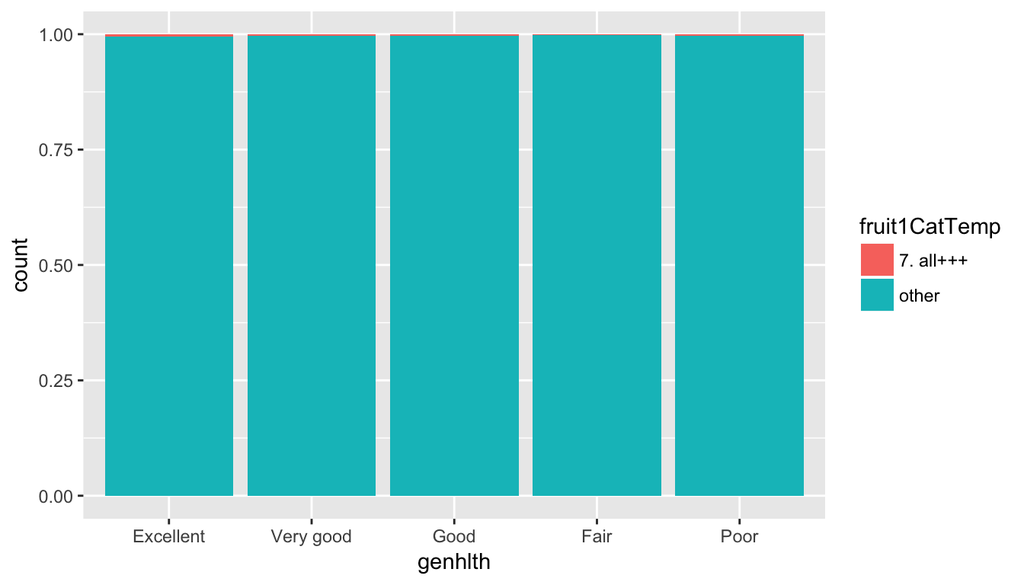

```r
a = c('0. never', '1. a little', '2. medium', '3. most', '4. all', '5. all+',  '6. all++',  '7. all+++')
for(i in a) {
  data_fruit_temp <- data_fruit %>% mutate(fruit1CatTemp = ifelse(fruit1Cat == i, i, 'other'))
  print(ggplot(data = data_fruit_temp, aes(x = genhlth, fill = fruit1CatTemp)) + geom_bar(position = "fill"))
}
```

Interestingly, the trend starts to change a bit later - in the `3. most` level. Just like with greens it stays negative after the first change point.

#### Recap:

Data analysis shows a strong correlation between the `eating green vegetables` and the `general health` variables as well as for the `eating fruits` and the `general health` ones. The results are a bit surprising for the author as he expected the correlation for the `fruit consumption`/`general health` variables, when the fruit consumption goes beyond some amount per day, to change the direction again - thus change the direction twice. This was not observed during the analysis.